# HW7-Jie He

# Section 6.8

# Q11(LASSO)

# a

```r
#library and data input
library(glmnet)
library(MASS)
data(Boston)
summary(Boston)
```

```
##       crim                zn             indus            chas
##  Min.   : 0.00632   Min.   :  0.00   Min.   : 0.46   Min.   :0.00000
##  1st Qu.: 0.08204   1st Qu.:  0.00   1st Qu.: 5.19   1st Qu.:0.00000
##  Median : 0.25651   Median :  0.00   Median : 9.69   Median :0.00000
##  Mean   : 3.61352   Mean   : 11.36   Mean   :11.14   Mean   :0.06917
##  3rd Qu.: 3.67708   3rd Qu.: 12.50   3rd Qu.:18.10   3rd Qu.:0.00000
##  Max.   :88.97620   Max.   :100.00   Max.   :27.74   Max.   :1.00000
##       nox               rm             age              dis
##  Min.   :0.3850   Min.   :3.561   Min.   :  2.90   Min.   : 1.130
##  1st Qu.:0.4490   1st Qu.:5.886   1st Qu.: 45.02   1st Qu.: 2.100
##  Median :0.5380   Median :6.208   Median : 77.50   Median : 3.207
##  Mean   :0.5547   Mean   :6.285   Mean   : 68.57   Mean   : 3.795
##  3rd Qu.:0.6240   3rd Qu.:6.623   3rd Qu.: 94.08   3rd Qu.: 5.188
##  Max.   :0.8710   Max.   :8.780   Max.   :100.00   Max.   :12.127
##       rad              tax           ptratio          black
##  Min.   : 1.000   Min.   :187.0   Min.   :12.60   Min.   :  0.32
##  1st Qu.: 4.000   1st Qu.:279.0   1st Qu.:17.40   1st Qu.:375.38
##  Median : 5.000   Median :330.0   Median :19.05   Median :391.44
##  Mean   : 9.549   Mean   :408.2   Mean   :18.46   Mean   :356.67
##  3rd Qu.:24.000   3rd Qu.:666.0   3rd Qu.:20.20   3rd Qu.:396.23
##  Max.   :24.000   Max.   :711.0   Max.   :22.00   Max.   :396.90
##      lstat            medv
##  Min.   : 1.73   Min.   : 5.00
##  1st Qu.: 6.95   1st Qu.:17.02
##  Median :11.36   Median :21.20
##  Mean   :12.65   Mean   :22.53
##  3rd Qu.:16.95   3rd Qu.:25.00
##  Max.   :37.97   Max.   :50.00
```

```r
#data split
set.seed(1)
training <- sample(1:nrow(Boston), nrow(Boston)/2) #50:50 split
train <- Boston[training,]
test <- Boston[-training,]
mat.train <- model.matrix(crim~., data = train)[,-1] #construct design matrices from training data
mat.test <- model.matrix(crim~., data = test)[,-1] #construct design matrices from test data
#lasso
lassofit <- cv.glmnet(mat.train, train$crim, alpha = 1)
lambda <- lassofit$lambda.min
lassopred <- predict(lassofit, s = lambda, newx = mat.test)
lassoerr <- mean((test$crim - lassopred)^2)  #mse
print(lassoerr)
```

```
## [1] 38.37664
```

```r
predict(lassofit, s = lambda, type = "coefficients") #predict coeffs
```

```
## 14 x 1 sparse Matrix of class "dgCMatrix"
##                        1
## (Intercept)  7.204613974
## zn           0.037084733
## indus       -0.034037718
## chas        -0.518884600
## nox         -9.663821285
## rm           1.187198535
## age          .
## dis         -0.971658064
## rad          0.517060059
## tax          .
## ptratio     -0.220503429
## black       -0.002432899
## lstat        0.176698759
## medv        -0.193172676
```

From the above, we can see the test MSE is 38.37664 for lasso. All the model coefficients are presented as well. Some features are dropped.

# b

```r
print(lassoerr)
```

```
## [1] 38.37664
```

The test MSE of LASSO is 38.37664 which is good. Some predictors are ignored in order to reduce model complexity which is good.

# c

No, it doesn’t. Because some of the features in the data set are just not useful to the model, they are thus eliminated.

# Section 7.9

# Q3

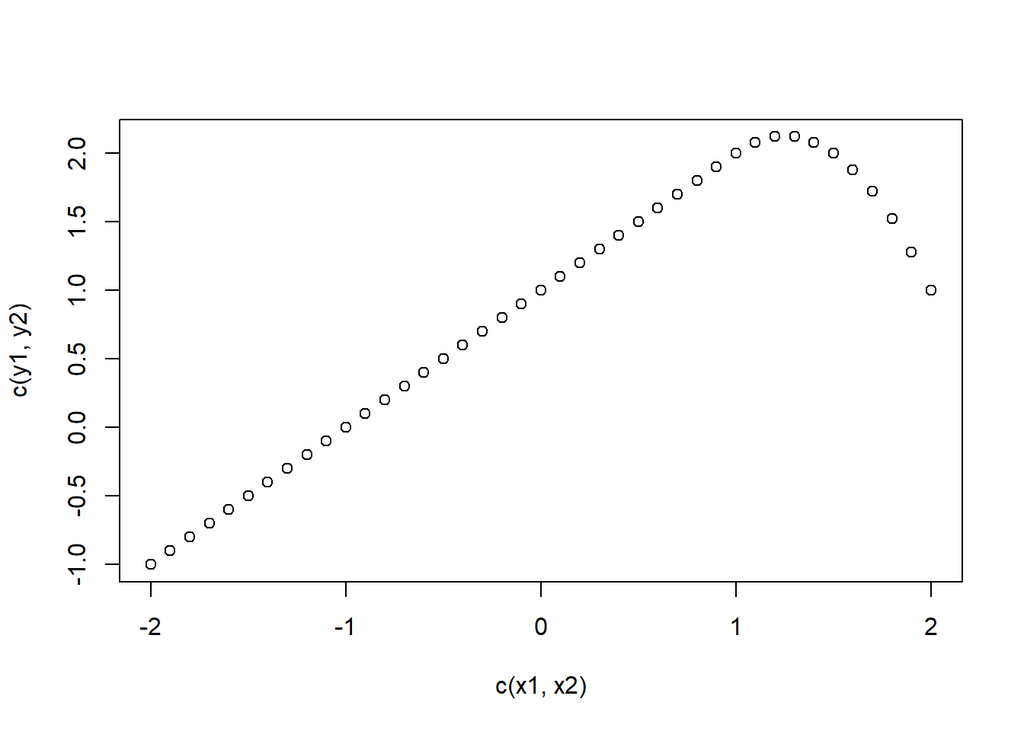

```r
x1 <- seq(-2,1,0.1)
x2 <- seq(1,2,0.1)
y1 <- 1+x1
y2 <- 1+x2-2*(x2-1)^2
plot(c(x1,x2),c(y1,y2)) #two parts of the model based on the intervals
```

When X<1, we have $Y=1+X$ slope:1, x-intercept:-1, y-intercept:1 When X>=1, we have $Y=1+X-2(X-1)^2$ slope:different at different points on the curve, x-intercept:$5/4+\sqrt{17}/4$, y-intercept:none

# Q9

# a

```r
#library and data loading
library(MASS)
data(Boston)
summary(Boston)
```

```
##       crim                zn             indus            chas
##  Min.   : 0.00632   Min.   :  0.00   Min.   : 0.46   Min.   :0.00000
##  1st Qu.: 0.08204   1st Qu.:  0.00   1st Qu.: 5.19   1st Qu.:0.00000
##  Median : 0.25651   Median :  0.00   Median : 9.69   Median :0.00000
##  Mean   : 3.61352   Mean   : 11.36   Mean   :11.14   Mean   :0.06917
##  3rd Qu.: 3.67708   3rd Qu.: 12.50   3rd Qu.:18.10   3rd Qu.:0.00000
##  Max.   :88.97620   Max.   :100.00   Max.   :27.74   Max.   :1.00000
##       nox               rm             age              dis
##  Min.   :0.3850   Min.   :3.561   Min.   :  2.90   Min.   : 1.130
##  1st Qu.:0.4490   1st Qu.:5.886   1st Qu.: 45.02   1st Qu.: 2.100
##  Median :0.5380   Median :6.208   Median : 77.50   Median : 3.207
##  Mean   :0.5547   Mean   :6.285   Mean   : 68.57   Mean   : 3.795
##  3rd Qu.:0.6240   3rd Qu.:6.623   3rd Qu.: 94.08   3rd Qu.: 5.188
##  Max.   :0.8710   Max.   :8.780   Max.   :100.00   Max.   :12.127
##       rad              tax           ptratio          black
##  Min.   : 1.000   Min.   :187.0   Min.   :12.60   Min.   :  0.32
##  1st Qu.: 4.000   1st Qu.:279.0   1st Qu.:17.40   1st Qu.:375.38
##  Median : 5.000   Median :330.0   Median :19.05   Median :391.44
##  Mean   : 9.549   Mean   :408.2   Mean   :18.46   Mean   :356.67
##  3rd Qu.:24.000   3rd Qu.:666.0   3rd Qu.:20.20   3rd Qu.:396.23
##  Max.   :24.000   Max.   :711.0   Max.   :22.00   Max.   :396.90
##      lstat            medv
##  Min.   : 1.73   Min.   : 5.00
##  1st Qu.: 6.95   1st Qu.:17.02
##  Median :11.36   Median :21.20
##  Mean   :12.65   Mean   :22.53
##  3rd Qu.:16.95   3rd Qu.:25.00
##  Max.   :37.97   Max.   :50.00
```

```r
#fit the cubic polynomial regression
set.seed(1)
poly3 <- lm(nox~poly(dis,3), data = Boston)
summary(poly3)
```

```
##
## Call:
## lm(formula = nox ~ poly(dis, 3), data = Boston)
##
## Residuals:
##       Min        1Q    Median        3Q       Max
## -0.121130 -0.040619 -0.009738  0.023385  0.194904
##
## Coefficients:
##                Estimate Std. Error t value Pr(>|t|)
## (Intercept)    0.554695   0.002759 201.021  < 2e-16 ***
## poly(dis, 3)1 -2.003096   0.062071 -32.271  < 2e-16 ***
## poly(dis, 3)2  0.856330   0.062071  13.796  < 2e-16 ***
## poly(dis, 3)3 -0.318049   0.062071  -5.124 4.27e-07 ***
## ---
## Signif. codes:  0 '***' 0.001 '**' 0.01 '*' 0.05 '.' 0.1 ' ' 1
##
## Residual standard error: 0.06207 on 502 degrees of freedom
## Multiple R-squared:  0.7148, Adjusted R-squared:  0.7131
## F-statistic: 419.3 on 3 and 502 DF,  p-value: < 2.2e-16
```

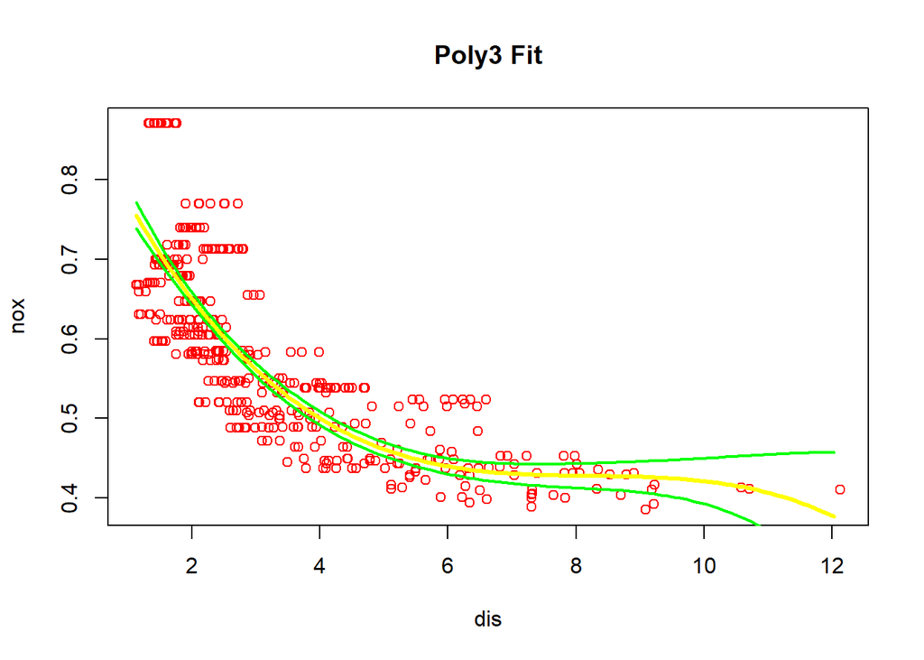

```r
#set parameters
disrange <- range(Boston$dis) #get x-axis range
disgrid <- seq(disrange[1], disrange[2], 0.1) #set x-axis grid
poly3pred <- predict(poly3, newdata = list(dis=disgrid), se=TRUE) #get corresponding y values and compute se
sefit <- poly3pred$fit + cbind(2*poly3pred$se.fit, -2*poly3pred$se.fit) #get se boundary
#plotting
plot(Boston$dis, Boston$nox, main = "Poly3 Fit", xlab = "dis", ylab = "nox", xlim=disrange, cex=1, col="red") #original
lines(disgrid, poly3pred$fit, lwd=3, col="yellow") #polynomial fit line
matlines(disgrid, sefit, lwd=2, col="green", lty=1) #standard error boundary
```

# b

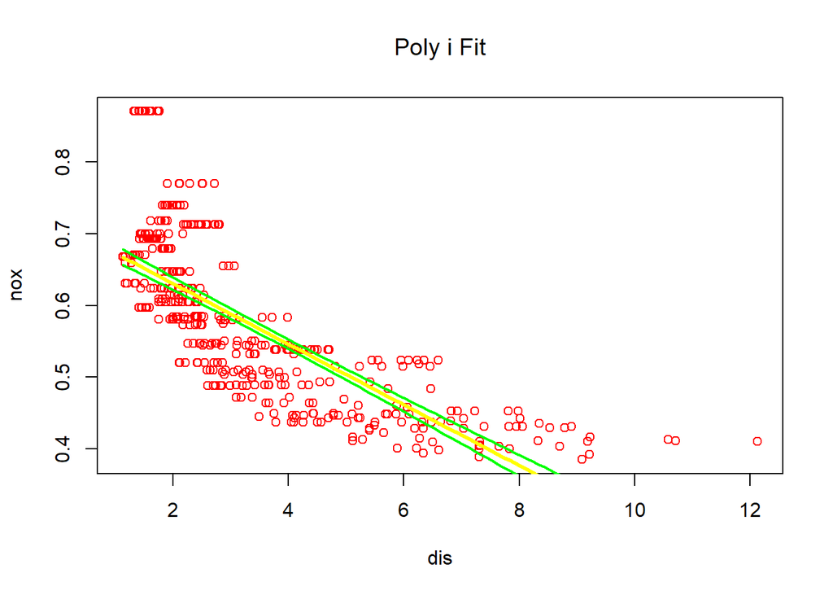

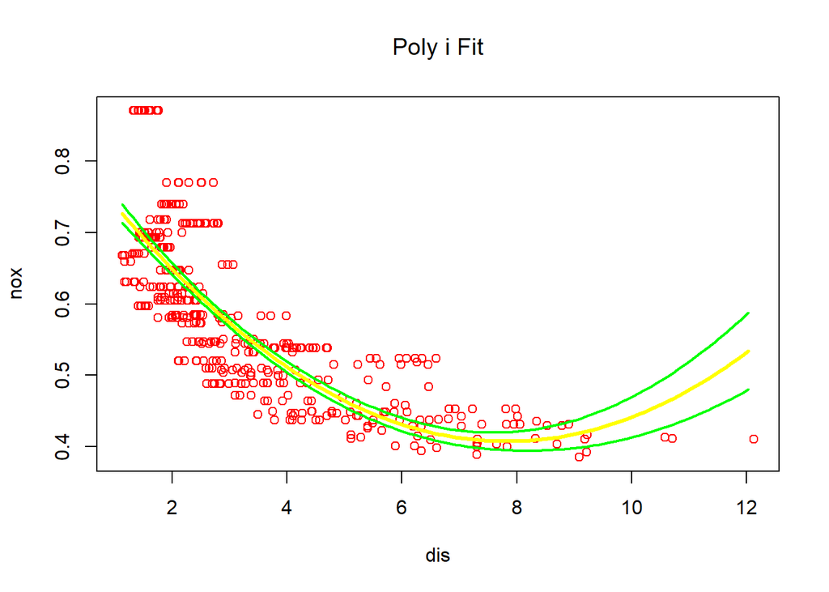

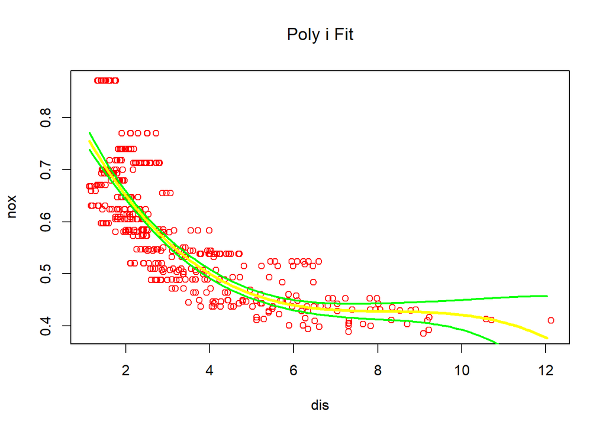

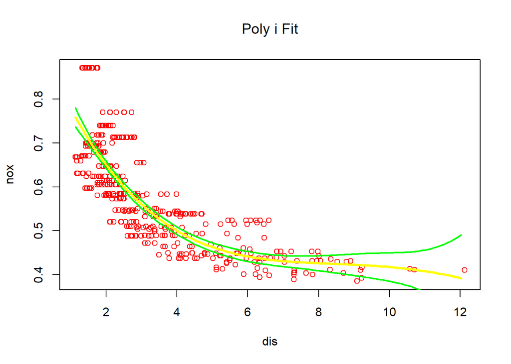

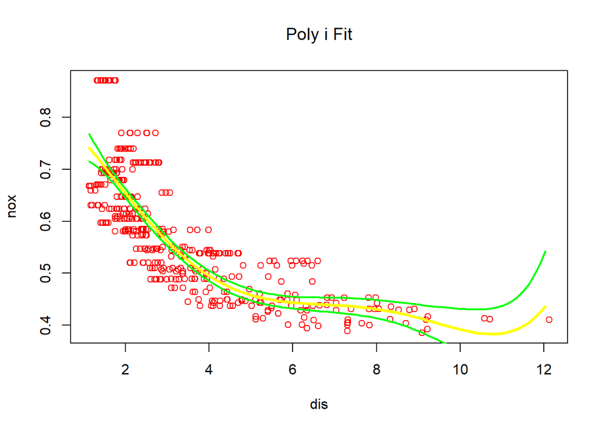

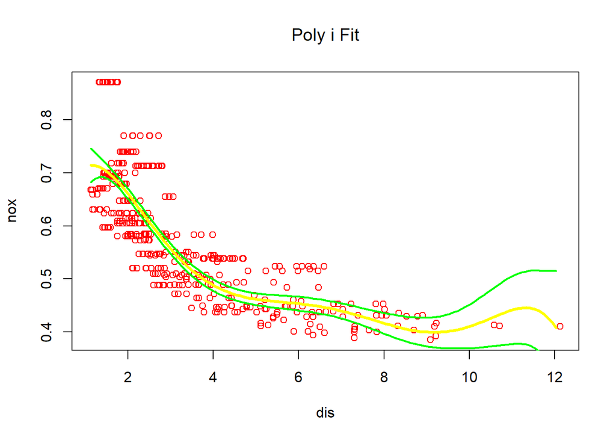

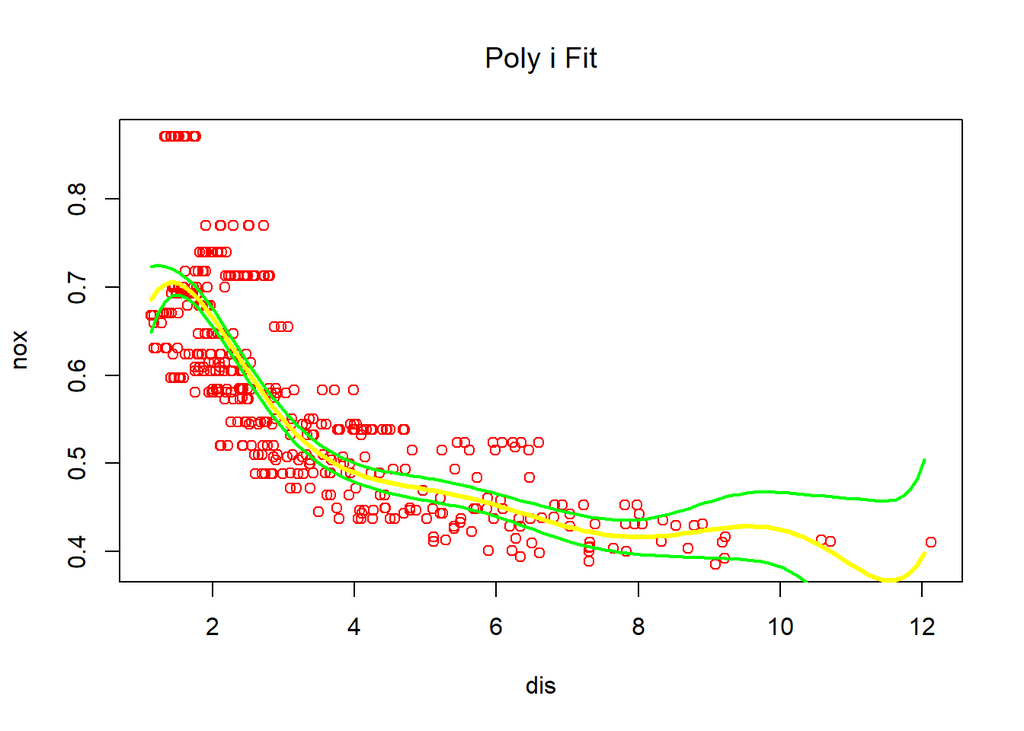

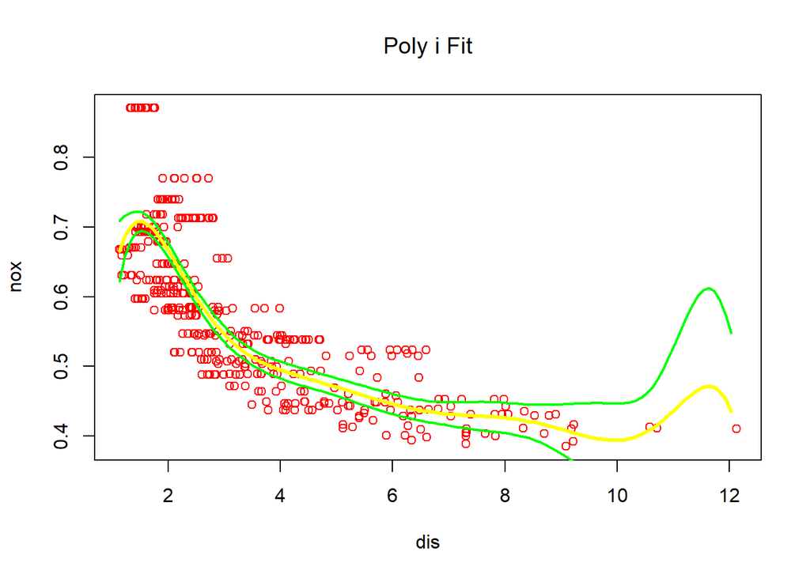

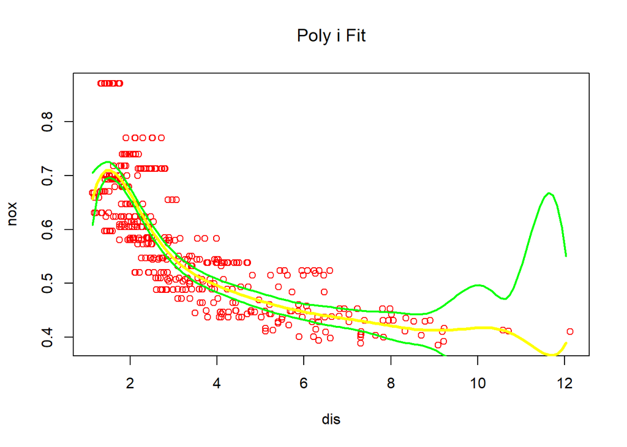

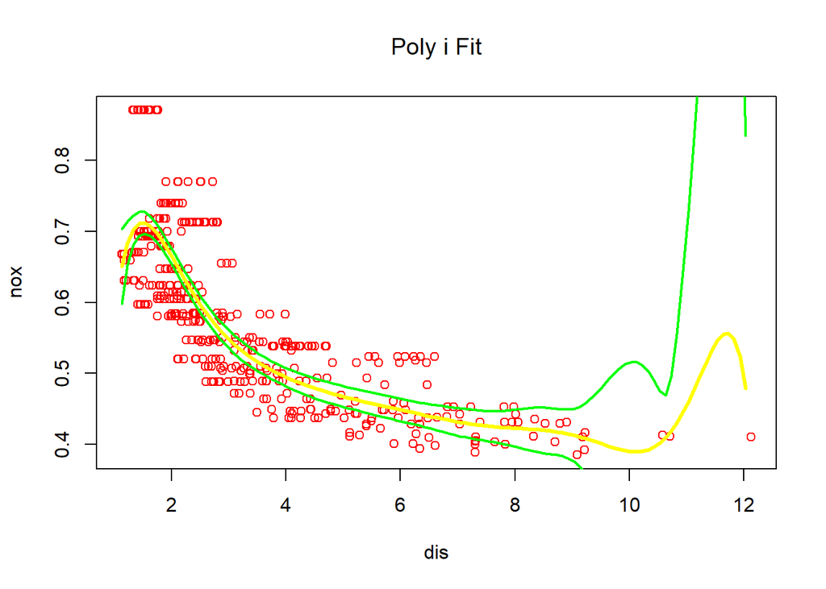

```r
rss_err <- rep(0,10) #initialize
#for loop for 10 different degrees
for (i in 1:10) {
  fitlm <- lm(nox~poly(dis,i), data = Boston)
  rss_err[i] <- sum(fitlm$residuals^2)
  #set parameters
  disrange_0 <- range(Boston$dis)
  disgrid_0 <- seq(disrange_0[1], disrange_0[2], 0.1)
  polyipred <- predict(fitlm, newdata = list(dis=disgrid_0), se=TRUE)
  sefit_0 <- polyipred$fit + cbind(2*polyipred$se.fit, -2*polyipred$se.fit)
  #plotting
  plot(Boston$dis, Boston$nox, main = substitute(paste('Poly ', i, ' Fit')), xlab = "dis", ylab = "nox", xlim=disrange_0, cex=1, col="red")
  lines(disgrid_0, polyipred$fit, lwd=3, col="yellow")
  matlines(disgrid_0, sefit_0, lwd=2, col="green", lty=1)
}
```

```r
print(rss_err)
```

```
##  [1] 2.768563 2.035262 1.934107 1.932981 1.915290 1.878257 1.849484
##  [8] 1.835630 1.833331 1.832171
```

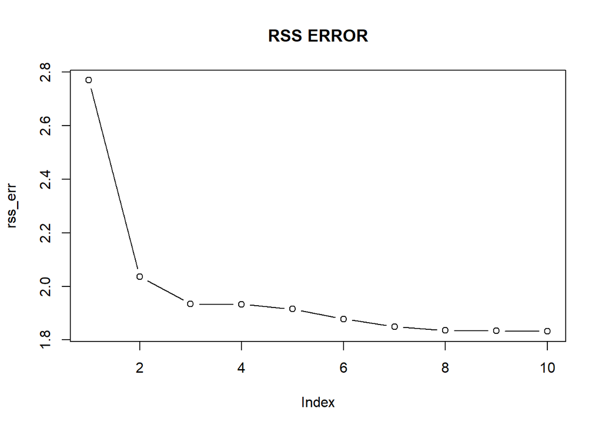

```r
plot(rss_err, main = "RSS ERROR", type = "b")
```

# c

```r
#import library to perform CV
library(boot)
set.seed(1)
cv_err <- rep(0,10) #initialize
#for loop for 10 different degrees
for (i in 1:10) {
  fitglm <- glm(nox~poly(dis,i), data = Boston)
  cv_err[i] <- cv.glm(Boston, fitglm, K=10)$delta[1]  #delta contains two numbers and we choose the standard one
} #10-fold CV
print(cv_err)
```

```
##  [1] 0.005536329 0.004077147 0.003899587 0.003862127 0.004298590
##  [6] 0.005095283 0.013680327 0.005284520 0.013355413 0.004148996
```

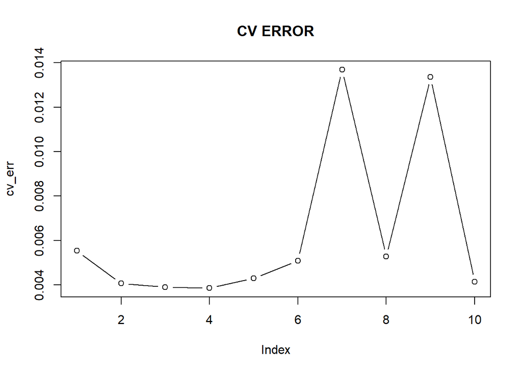

```r
plot(cv_err, main = "CV ERROR", type = "b")
```

From the above, we can see that the optimal degree for the polynomial is 4 since it yields the smallest cv error.